# Analysis of Berlin Boroughs

# Visual Insights: Crime and Lifestyle

- Strong positive correlations exist between crime and **Cultural/Nightlife Scores**.
- Weak negative correlations for crime and **Family/Pet Scores**.
- Visualized below is a heatmap of the correlations.

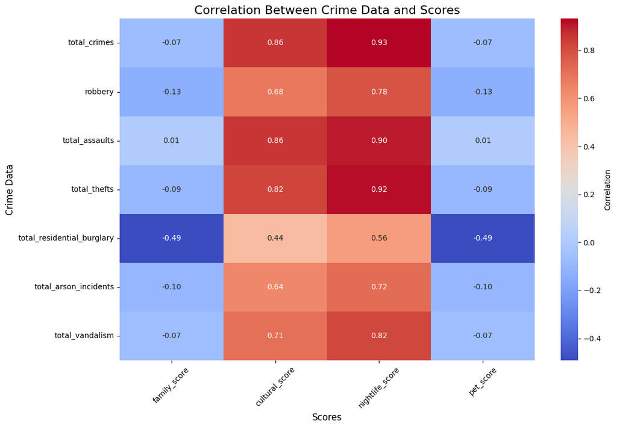

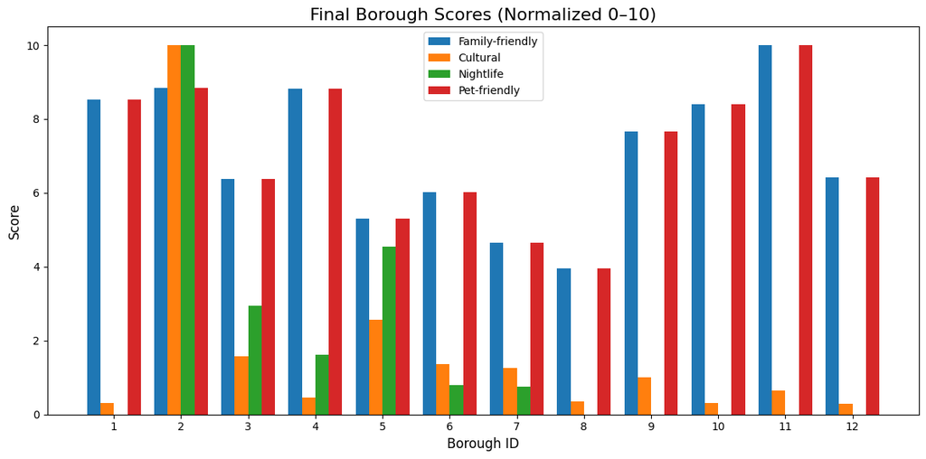

# Recommendations

1. **Borough Development**:
   - Focus on enhancing Family- and Pet-friendly amenities in Borough 5.
   - Increase safety measures in Boroughs 2 and 6 to boost their attractiveness for families.
2. **Safety Interventions**:
   - Address high crime rates in Borough 2 to sustain its Cultural and Nightlife appeal.
3. **Strategic Marketing**:
   - Market Boroughs 1 and 4 as ideal residential areas for families and pet owners.
   - Highlight Borough 2 as a hub for culture and nightlife, targeting younger demographics.

# Conclusion

This analysis provides a data-driven overview of Berlin’s boroughs:

1. Scores were computed based on amenities, demographics, and crime data.
2. Adjustments ensured fairness, incorporating safety and livability.
3. Recommendations aim to assist urban planning and lifestyle-focused policies.

The findings offer actionable insights for both residents and city planners.